# SeeGEM Test Report

July 04, 2019

# outside

## GEMINI Variation

| test | pos_id | impact_so | gene | hgvsc | hgvsp | aaf | gno_af_all | exac_num_hom_alt | clinvar_id | rs_ids | GoogleScholar | family_members | family_genotypes | cadd_phred | ccr_pct_v1 | polyphen_score | sift_score | metalr_rankscore | genesplicer | spliceregion | linsight | Color | num_hom_ref | num_het | num_hom_alt | num_unknown | codon_change | aachange_refgenewithver_annovar | alt_annovar | … |
| --- | --- | --- | --- | --- | --- | --- | --- | --- | --- | --- | --- | --- | --- | --- | --- | --- | --- | --- | --- | --- | --- | --- | --- | --- | --- | --- | --- | --- | --- | --- |
| autosomal recessive | 1-145296424-G-T | missense variant | NBPF10 | ENST00000342960.5: c.346G>T | ENSP00000345684.5: p.Gly116Trp | 0.667 | 0.00702 | 3.0 |  | rs186121989 | Feeling lucky? | Proband(Proband;affected)Father(Father;unaffected;male)Mother(Mother;unaffected;female) | T\|TT\|GT\|G | 23 | -1 | 0.955 | 0 | -1 |  |  | -1 | 1 | 0 | 2 | 1 | 0 | Ggg/Tgg | NBPF10:NM 001039703.6:exon3:c.346G>T:p.G116W | T | … |
| autosomal recessive | 1-145365369-T-G | missense variant | NBPF10 | ENST00000342960.5: c.9994T>G | ENSP00000345684.5: p.Cys3332Gly | 0.667 | 0.00759 | 13.0 |  | rs587599645 | Feeling lucky? | Proband(Proband;affected)Father(Father;unaffected;male)Mother(Mother;unaffected;female) | G\|GG\|TG\|T | 0.008 | -1 | 0 | 0.16 | 0.01027 |  |  | -1 | 1 | 0 | 2 | 1 | 0 | Tgt/Ggt | NBPF10:NM 001039703.6:exon68:c.8524T>G:p.C2842G | G | … |
| autosomal recessive | 15-30437693-C-G | missense variant | GOLGA8T | ENST00000569052.1: c.1819C>G | ENSP00000455826.1: p.Gln607Glu | 0.667 | 0.115 | -1 |  | rs201978730 | Feeling lucky? | Proband(Proband;affected)Father(Father;unaffected;male)Mother(Mother;unaffected;female) | G\|GG\|CG\|C | 11 | -1 | 0.962 | 0.04 | . |  |  | -1 | 1 | 0 | 2 | 1 | 0 | Cag/Gag | GOLGA8T:NM 001355469.1:exon19:c.1819C>G:p.Q607E | G | … |

## peddy QC

A small selection of outputs from the [peddy](http://peddy.readthedocs.io) tool.

For the plots, gray are all of the samples available in the vcf that [peddy](http://peddy.readthedocs.io) was run on. The colored points are samples in the family analyzed in this document.

### [peddy](http://peddy.readthedocs.io) Heterozygousity Check

- Median Read Depth: Median depths for the sites tested.
- Het Ratio: proportion of sites that were heterozygous.
- IDR BAF: inter-decile range (90th percentile - 10th percentile) of b-allele frequency. Large values indicate likely sample contamination.

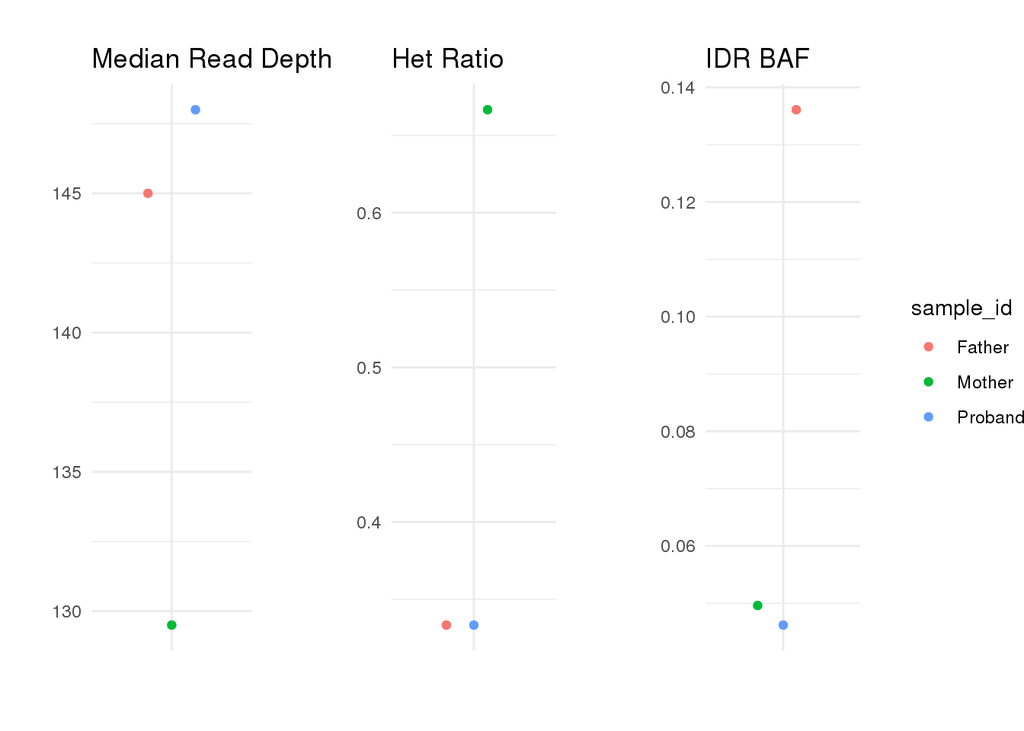

### [peddy](http://peddy.readthedocs.io) Sex Check

- ped Sex: Sex from .ped file
- Predicted Sex: Sex predicted from rate of heterozygotes on chrX
- Error: Deviation between given and predicted sex

| Sample ID | Pedigree Sex | Predicted Sex | Error |
| --- | --- | --- | --- |
| Father | male | male | False |
| Mother | female | male | True |
| Proband | unknown | female | True |

### [peddy](http://peddy.readthedocs.io) Pedigree Check

- Relatedness: the relatedness calculated from the genotypes.
- IBS2 against IBS0: IBS0 is the number of sites where the two samples shared no alleles (~0 for parent-child) and IBS2 is where the two samples were both homozygous reference, heterozygous, or homozyous alternative. This should be fairly high between related individuals. An intermediate IBS0 suggests first cousin or second cousin.

| Sample 1 | Sample 2 | Relatedness | ibs0 | ibs2 | Pedigree Parents | Predicted Parents | Parent Error |
| --- | --- | --- | --- | --- | --- | --- | --- |
| Father | Mother | 1 | 0 | 4 | False | True | True |
| Father | Proband | 0.5 | 0 | 4 | True | True | False |
| Mother | Proband | 1 | 0 | 4 | True | True | False |

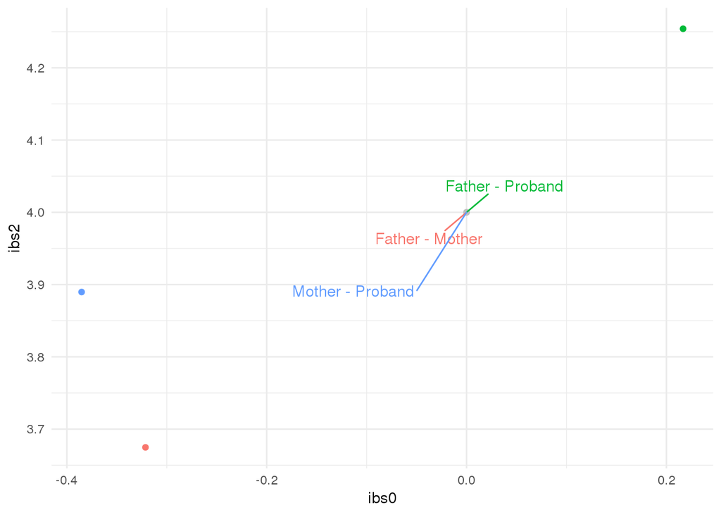

## Info

This report is auto-generated with the [See GEM](https://github.com/davemcg/See_GEM) R package on July 04, 2019

The analyst for this report populated the information in this dynamic documents with a variety of GEMINI queries.

**FAQ**:

- What does it mean if a variant is marked in red?
- This means that the variant has an impact severity of [HIGH](http://gemini.readthedocs.io/en/latest/content/database_schema.html#details-of-the-impact-and-impact-severity-columns) **or** is marked as pathogenic in ClinVar **and** has a gnomAD population allele frequency less than 1%.
- Orange?
- [MED](http://gemini.readthedocs.io/en/latest/content/database_schema.html#details-of-the-impact-and-impact-severity-columns) impact severity

**WARNINGS/LIMITATIONS**

- This document is only a tool to aid identification of causative variant(s)
- The *in silico* consequences (e.g. stop gained, synonymous) are automatically calculated, and for a variety of reasons, may not be accurate.
- The causative variants may not be present in this document